# Clase repaso

## Fundación Universitaria Konrad Lorenz

### Especialización en Analítica de Datos

#### Diseño Estadístico en Proyectos de Analítica

## 0. Introducción

En cualquier análisis estadístico siempre debemos realizar un descriptivo de la muestra con un doble objetivo:

1. Comprobar la calidad de los datos
2. Conocer detalladamente los datos. Esto nos ayudará a decidir la estrategia de análisis más adecuada.

## 1. ¿Cómo leemos los datos en R?

Existen varias funciones de lectura de datos en R según el formato del archivo. Cuando tenemos un fichero en excel, es aconsejable guardarlo previamente en formato csv y posteriormente lo leemos desde R con la función **read.csv**:

```r
datos <- read.csv("train_Rest/riesgos.csv", header = T, sep = "\t", encoding = "UTF-8")

## Algunas funciones para explorar los datos:
head(datos)
```

```
##   id contrato  jornada turno carfisi carpsiqui expquímica edad peso talla
## 1  2        3 completa     1      no        no         no   33   74   155
## 2  3        1 completa     1      no        no         no   37   74   170
## 3  6        5 completa     1      sí        no         no   35   67   170
## 4  7        1 completa     1      sí        no         no   30   57   164
## 5  8        3 completa     1      sí        no         sí   30   69   160
## 6 10        2 completa     1      no        sí         no   32   56   160
```

```r
tail(datos)
```

```
##    id contrato jornada turno carfisi carpsiqui expquímica edad peso talla
## 86 73        5 parcial     1      no        no         no   32   65   159
## 87 75        1 parcial     1      no        no         no   33   87   185
## 88 76        1 parcial     1      sí        no         no   30   76   178
## 89 80        4 parcial     1      no        no         no   29   65   153
## 90 82        1 parcial     1      no        no         no   35   78   190
## 91 86        4 parcial     4      no        no         no   28   65   167
```

```r
colnames(datos)
```

```
##  [1] "id"         "contrato"   "jornada"    "turno"      "carfisi"
##  [6] "carpsiqui"  "expquímica" "edad"       "peso"       "talla"
```

```r
dim(datos)
```

```
## [1] 91 10
```

```r
summary(datos)
```

```
##        id          contrato         jornada       turno       carfisi carpsiqui
##  Min.   : 1.0   Min.   :1.000   completa:67   Min.   :1.000   no:57   no:46
##  1st Qu.:23.5   1st Qu.:1.000   parcial :24   1st Qu.:1.000   sí:34   sí:45
##  Median :46.0   Median :1.000                 Median :1.000
##  Mean   :46.0   Mean   :1.857                 Mean   :1.209
##  3rd Qu.:68.5   3rd Qu.:3.000                 3rd Qu.:1.000
##  Max.   :91.0   Max.   :5.000                 Max.   :4.000
##
##  expquímica      edad            peso           talla
##  no:86      Min.   :23.00   Min.   :50.00   Min.   :150.0
##  sí: 5      1st Qu.:29.00   1st Qu.:62.00   1st Qu.:160.0
##             Median :31.00   Median :69.00   Median :165.0
##             Mean   :31.45   Mean   :70.34   Mean   :166.3
##             3rd Qu.:34.00   3rd Qu.:76.00   3rd Qu.:171.0
##             Max.   :39.00   Max.   :98.00   Max.   :190.0
##                             NA's   :2
```

```r
attach(datos)
```

## 2. Descripción numérica de una variable

### 2.1. Variables cuantitativas:

```r
edad <- datos$edad
summary(edad)
```

```
##    Min. 1st Qu.  Median    Mean 3rd Qu.    Max.
##   23.00   29.00   31.00   31.45   34.00   39.00
```

```r
sd(edad)
```

```
## [1] 3.442427
```

```r
sum(edad)
```

```
## [1] 2862
```

```r
is.na(edad)
```

```
##  [1] FALSE FALSE FALSE FALSE FALSE FALSE FALSE FALSE FALSE FALSE FALSE FALSE
## [13] FALSE FALSE FALSE FALSE FALSE FALSE FALSE FALSE FALSE FALSE FALSE FALSE
## [25] FALSE FALSE FALSE FALSE FALSE FALSE FALSE FALSE FALSE FALSE FALSE FALSE
## [37] FALSE FALSE FALSE FALSE FALSE FALSE FALSE FALSE FALSE FALSE FALSE FALSE
## [49] FALSE FALSE FALSE FALSE FALSE FALSE FALSE FALSE FALSE FALSE FALSE FALSE
## [61] FALSE FALSE FALSE FALSE FALSE FALSE FALSE FALSE FALSE FALSE FALSE FALSE
## [73] FALSE FALSE FALSE FALSE FALSE FALSE FALSE FALSE FALSE FALSE FALSE FALSE
## [85] FALSE FALSE FALSE FALSE FALSE FALSE FALSE
```

```r
## También es posible pedir un descriptivo de varias variables cuantitativas al mismo tiempo:
summary(datos[, c("edad","peso","talla")])
```

```
##       edad            peso           talla
##  Min.   :23.00   Min.   :50.00   Min.   :150.0
##  1st Qu.:29.00   1st Qu.:62.00   1st Qu.:160.0
##  Median :31.00   Median :69.00   Median :165.0
##  Mean   :31.45   Mean   :70.34   Mean   :166.3
##  3rd Qu.:34.00   3rd Qu.:76.00   3rd Qu.:171.0
##  Max.   :39.00   Max.   :98.00   Max.   :190.0
##                  NA's   :2
```

### 2.2. Variables categóricas:

Obtenemos tablas de frecuencias absolutas con el comando **table**:

```r
jornada <- datos$jornada
table(jornada)
```

```
## jornada
## completa  parcial
##       67       24
```

También es posible obtener tablas de frecuencias relativas combinando los comandos **table** con **margin.table**:

```r
  table(jornada)/ margin.table(table(jornada))
```

```
## jornada
##  completa   parcial
## 0.7362637 0.2637363
```

### 2.3. Ejercicios:

Tenemos una base de datos llamada **estrés** que incluye información sobre 90 trabajadores acerca de su nivel de estrés y diversas variables relacionadas con el puesto de trabajo.

A. Lee los datos en R utilizando la función **read.csv**.

B. ¿Qué variables contiene esta base de datos? (utiliza la función **head**)

C. Clasifica las variables según sean cuantitativas o categóricas. A continuación descríbelas utilizando los procedimientos que hemos visto anteriormente: tablas de frecuencias y descriptivos (en función del tipo de variable)

## 3. Descripción gráfica de una variable

### Introducción a los gráficos en R:

Los comandos de R son funciones que incluyen un conjunto de argumentos separados por comas y todos ellos entre paréntesis:

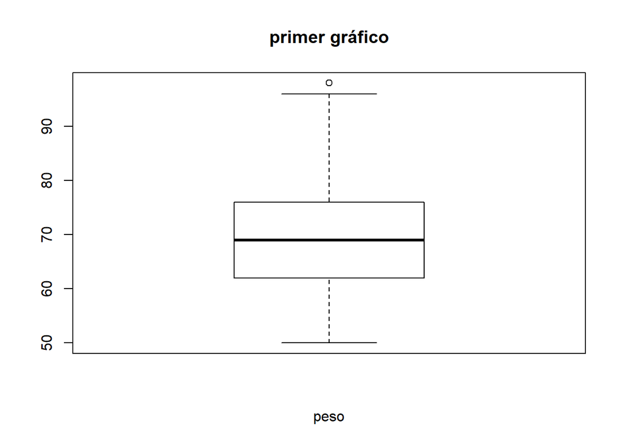

```r
boxplot(datos$peso, main = "primer gráfico", xlab = "peso")
```

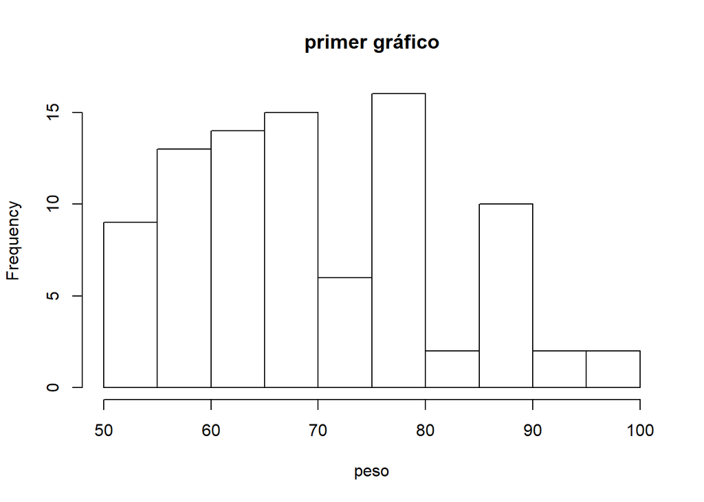

```r
hist(datos$peso, main = "primer gráfico", xlab = "peso")
```

Argumentos generales que utilizaremos en los gráficos: **main**: *Título principal del gráfico*

**xlab**: *Etiqueta para el eje X*

**ylab**: *Etiqueta para el eje Y*

**col**: *vector de colores*

### 3.1. Variables cuantitativas:

Hay varias opciones: box-plots, histogramas,… Con un interrogante delante del nombre de la función obtenemos ayuda sobre su uso: **?boxplot**

Es posible incluir o modificar elementos en el gráfico: Incluimos color en la caja

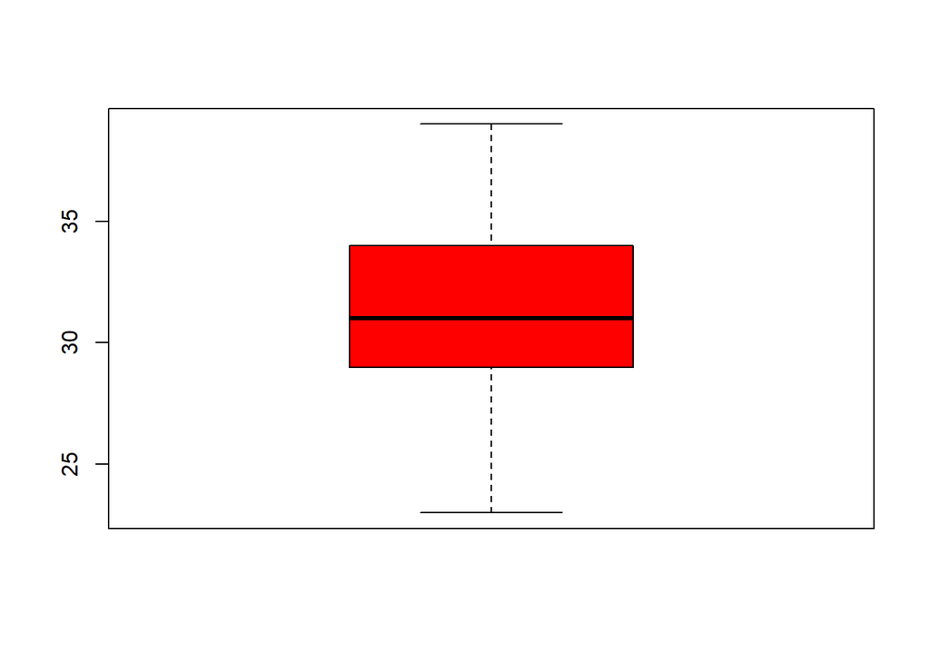

```r
boxplot(edad, col = "red")
```

Añadimos un título principal y subtítulo para el eje X

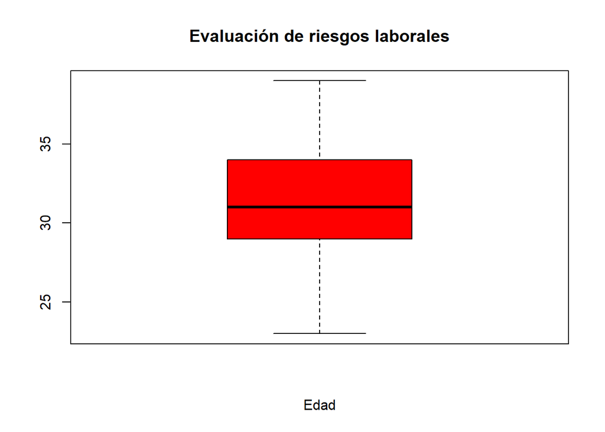

```r
 boxplot(edad, col = "red", main = "Evaluación de riesgos laborales", xlab = "Edad")
```

Modificamos la escala del eje Y

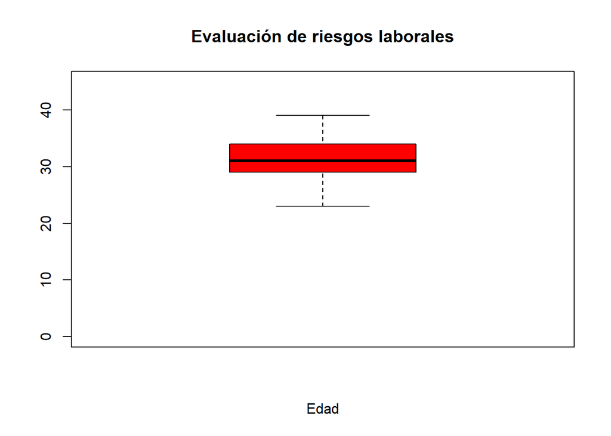

```r
 boxplot(edad, col = "red", main = "Evaluación de riesgos laborales", xlab = "Edad",
        ylimit = c(0,45))
```

### 3.2. Variables categóricas:

Comandos en R: **table(x)** para obtener la tabla de frecuencias **pie(table(x))** genera un gráfico de sectores **barplot(table(x))** genera un diagrama de barras

Los diagramas de barras son preferibles a los diagramas de sectores.

Preparamos una tabla de frecuencias

```r
contrato <- as.factor(datos$contrato)
table(contrato)
```

```
## contrato
##  1  2  3  4  5
## 59  6 12  8  6
```

Generamos el diagrama de sectores

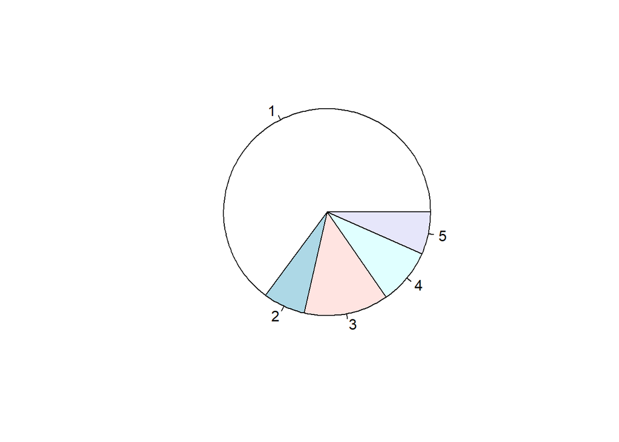

```r
pie(table(contrato))
```

Seleccionamos colores que nos gusten más para cada sector del gráfico:

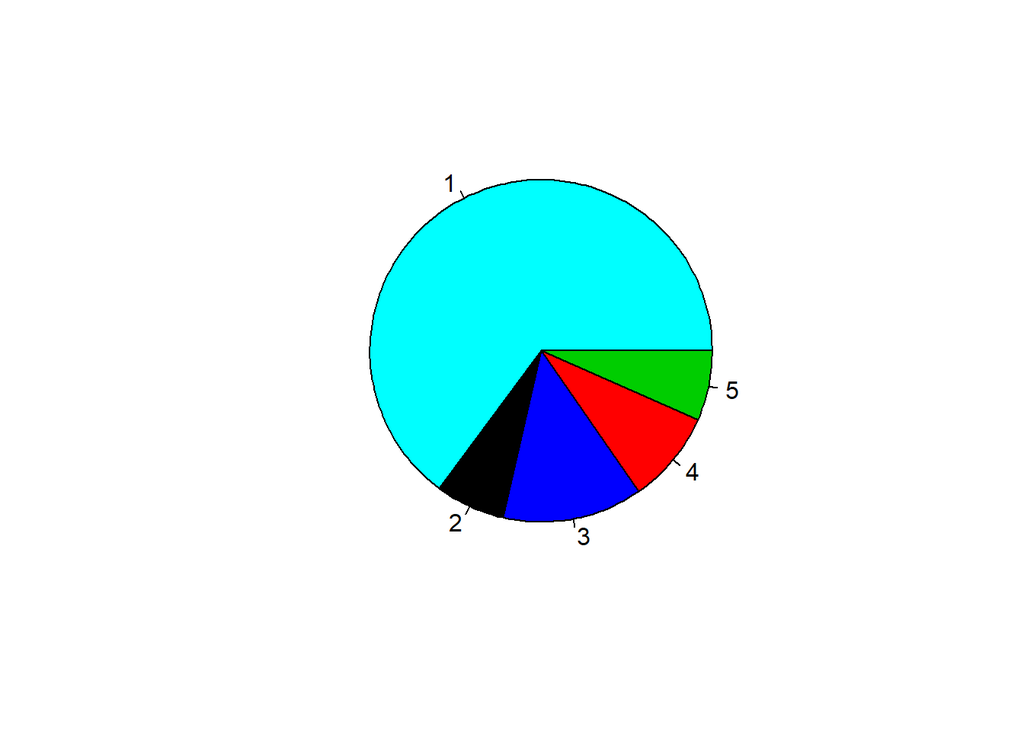

```r
color <- c('red', 'blue', 'pink', 'green', 'grey', 'yellow')
pie(table(contrato), col = as.factor(color) )
```

Además incluimos un título

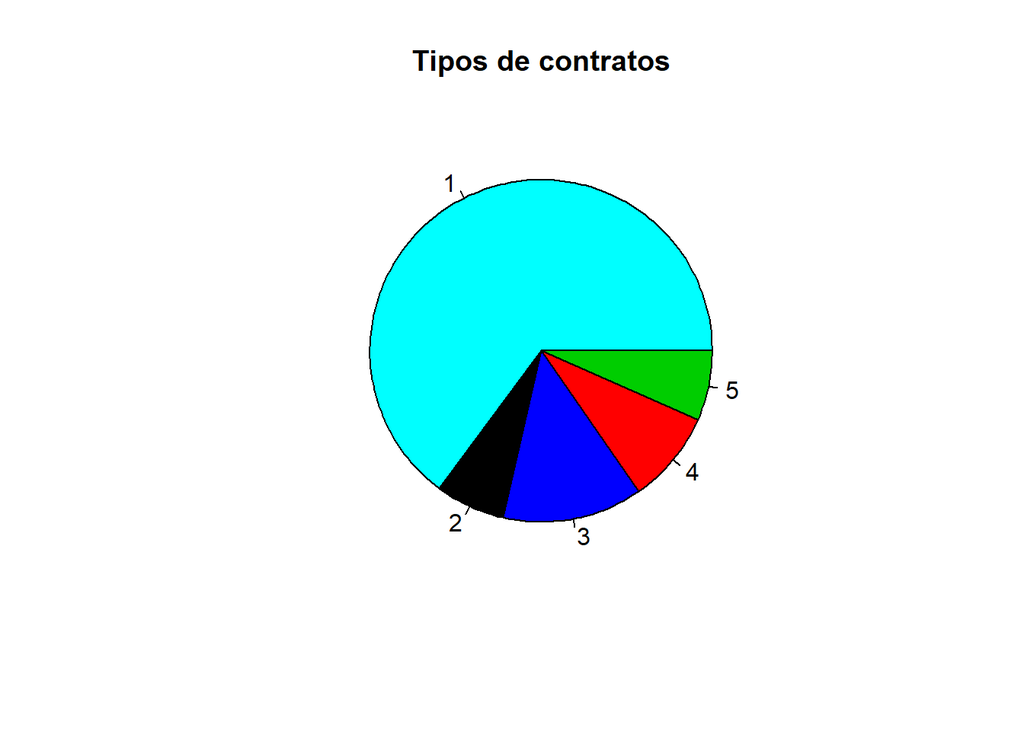

```r
pie(table(contrato),  col = as.factor(color), main = "Tipos de contratos")
```

**3.2.2. Gráficos de barras:** Este tipo de gráficos son útiles para representar variables categóricas o variables cuantitativas discretas

Preparamos una tabla de frecuencias

```r
table(contrato)
```

```
## contrato
##  1  2  3  4  5
## 59  6 12  8  6
```

Generamos el diagrama de barras

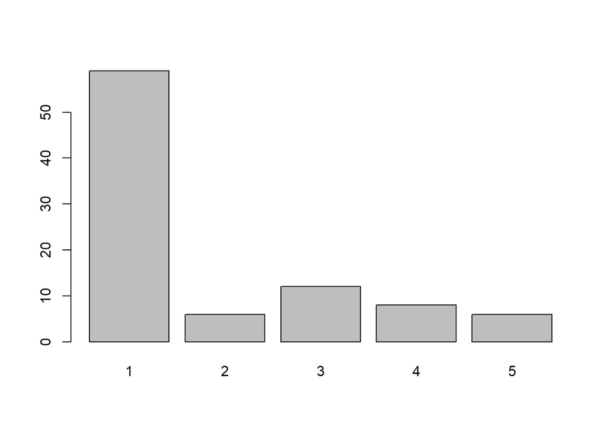

```r
barplot(table(contrato))
```

Incluimos título del gráfico y títulos para los ejes X,Y.

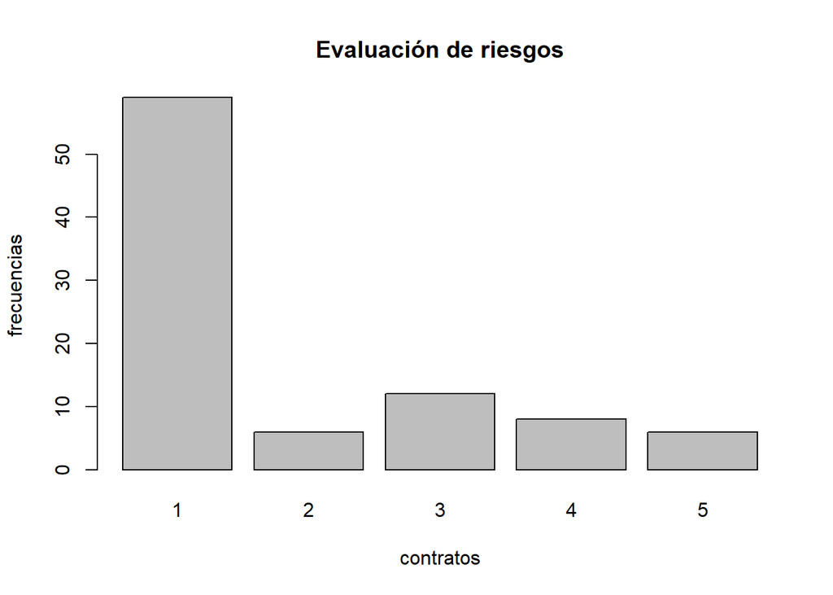

```r
barplot(table(contrato), xlab = "contratos", ylab = "frecuencias",
        main = "Evaluación de riesgos")
```

Cambiamos el modo de visualización y añadimos color a las barras

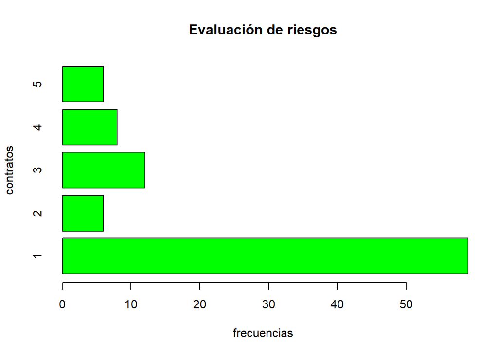

```r
barplot(table(contrato), horiz = TRUE,
        ylab = "contratos", xlab = "frecuencias",
        main = "Evaluación de riesgos",
        col = "green")
```

### 3.3. Ejercicios: Continuamos con la base de datos llamada **estrés**:

A. Describe gráficamente la variable **nivel de estrés** utilizando un **diagrama de barras**. - Incluye un título principal para el gráfico y también subtítulos para los ejes X e Y. - Las barras las colorearemos en verde (pista: col = “green”)

B. Describe gráficamente la variable **sueldo** utilizando un diagrama de cajas (**boxplot**). - Colorea la caja en azul. - Incluye como título príncipal “Salario de trabajadores del Hospital Dr. Peset”. El nombre del eje Y será “euros brutos / año”. - Comenta cada uno de los elementos del gráfico: cuartiles, rango de la variable, presencia de valores anómalos. - ¿La variable tiene una distribución normal?

C. Describe gráficamente la variable **jornada** utilizando un **diagrama pastel o de sectores**. - ¿Cuántas tipos de jornadas presenta esta variable? Escoge un color para cada una de ellas en el gráfico. - Incluye un título para el gráfico.

## 4. Descripción de relaciones entre parejas de variables

### 4.1. Varias variables categóricas

Obtenemos **tablas de contingencia** para dos variables categóricas utilizando comando **table**:

```r
table(jornada, carfisi)
```

```
##           carfisi
## jornada    no sí
##   completa 38 29
##   parcial  19  5
```

También es posible estratificar la información anterior por una tercera variable:

```r
table(jornada, carfisi, carpsiqui)
```

```
## , , carpsiqui = no
##
##           carfisi
## jornada    no sí
##   completa 14 14
##   parcial  14  4
##
## , , carpsiqui = sí
##
##           carfisi
## jornada    no sí
##   completa 24 15
##   parcial   5  1
```

La relación entre **jornada** y **carga física** se puede representar gráficamente:

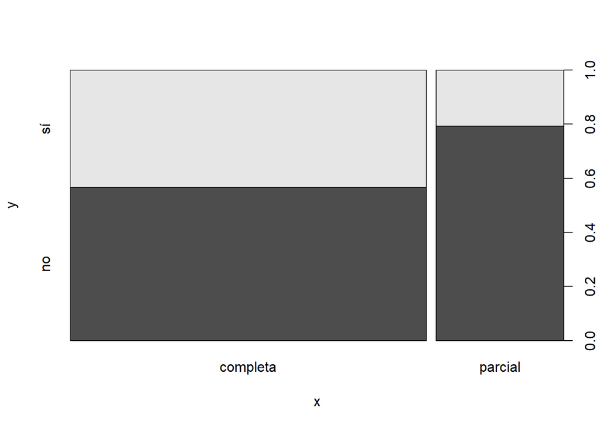

```r
plot(jornada, carfisi)
```

### 4.2. Variable categórica vs. variable cuantitativa *¿Qué relación hay entre la edad y la jornada?* Lo vemos gráficamente:

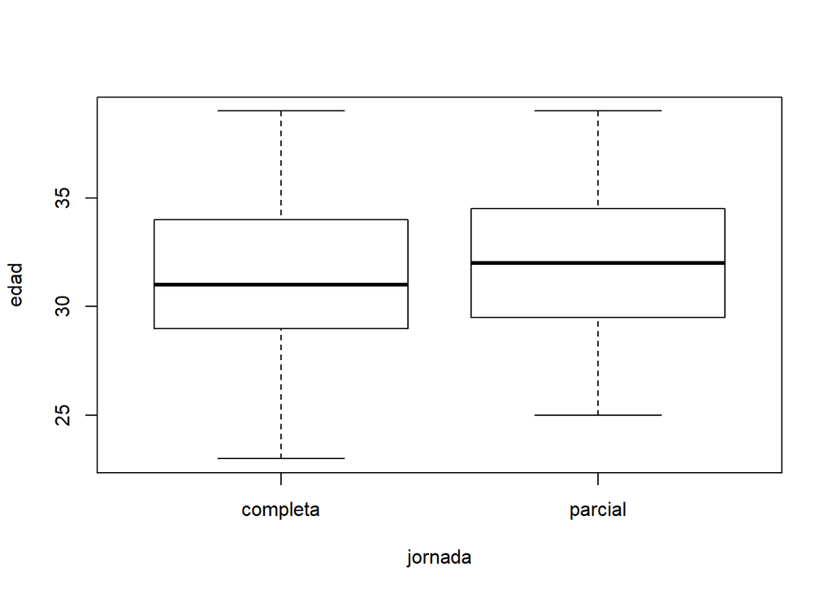

```r
boxplot(edad ~ jornada)
```

*¿Qué relación hay entre la edad y la carfisi?*

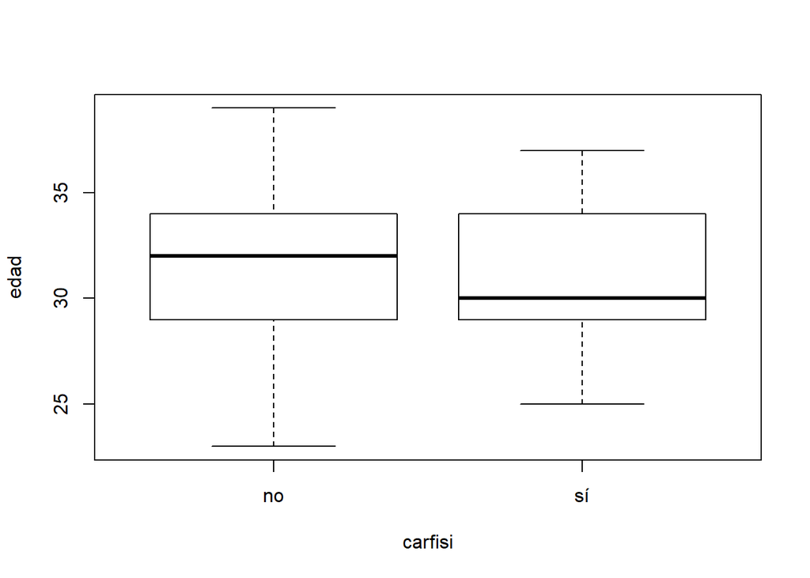

```r
boxplot(edad ~ carfisi)
```

### 4.3. Variable cuantitativa vs. variable cuantitativa *¿Qué relación hay entre el peso y la talla?*

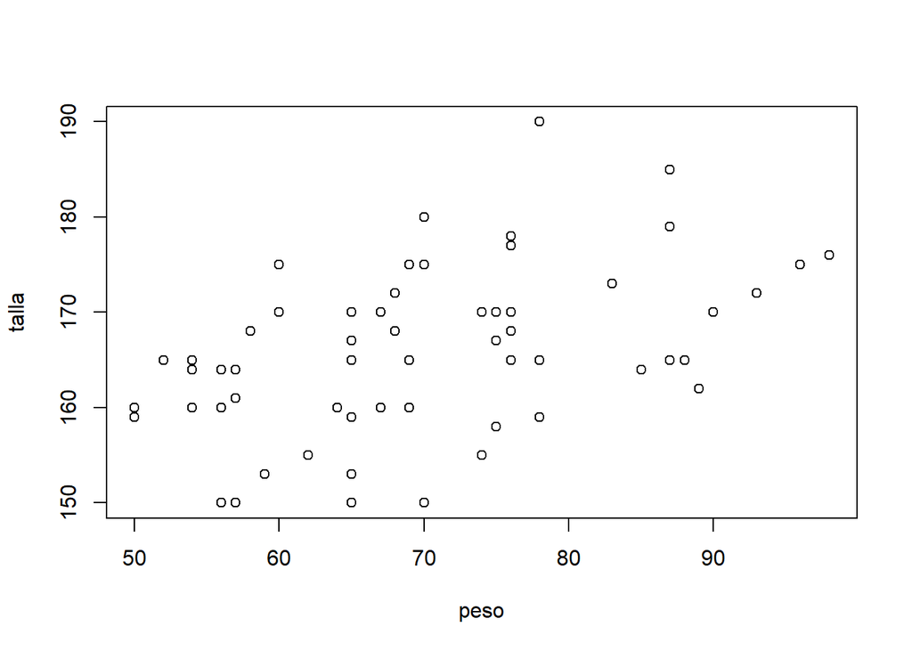

```r
plot(peso, talla)
```

representamos cada sujeto con triángulos azules

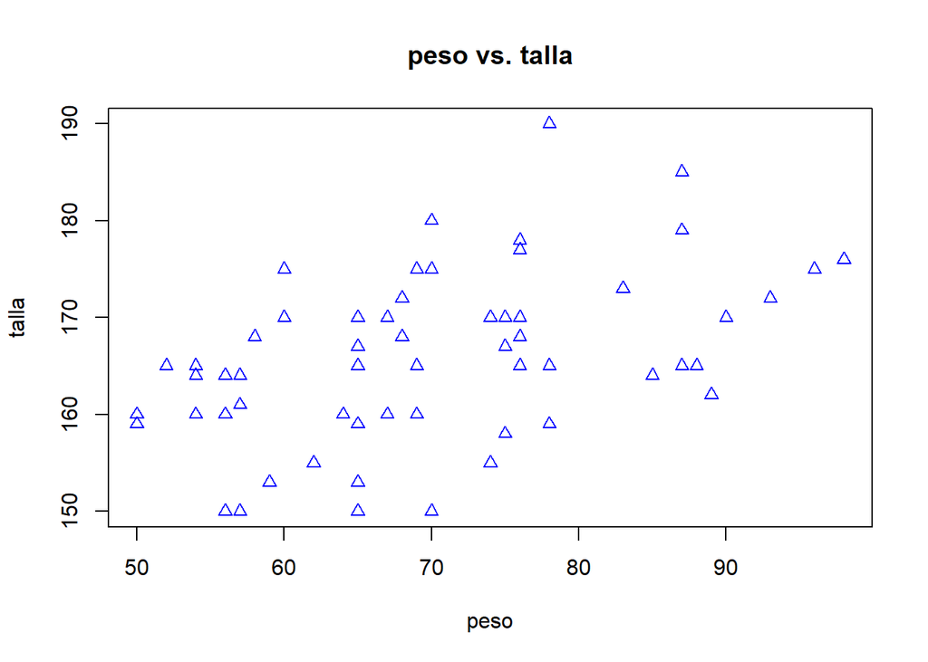

```r
plot(peso, talla, pch = 2, col = "blue", main = "peso vs. talla")
```

un poco más grandes!

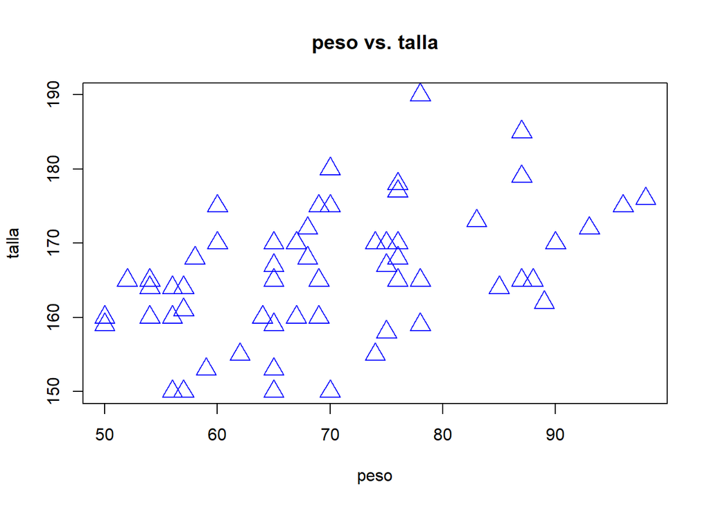

```r
plot(peso, talla, pch = 2, col = "blue", main = "peso vs. talla", cex=2)
```

*¿Se podría cuantificar la relación entre estas dos variables cuantitativas?* Sí, mediante un coeficiente de correlación:

```r
cor.test(peso,talla)
```

```
##
##  Pearson's product-moment correlation
##
## data:  peso and talla
## t = 5.3627, df = 87, p-value = 6.67e-07
## alternative hypothesis: true correlation is not equal to 0
## 95 percent confidence interval:
##  0.3237866 0.6402328
## sample estimates:
##       cor
## 0.4984336
```

### 4.4. Ejercicios:

Continuamos con la base de datos llamada **estrés**:

A. ¿Qué relación hay entre las variables **sueldo** y **edad**? Primero utiliza un gráfico que nos informe de la relación entre ambas variables y luego cuantifícala mediante un coeficiente de correlación.

B. **Salario vs. género**. ¿Quién cobra más en promedio, los hombres o las mujeres? Representa gráficamente ambas variables para describir la distribución de los salarios en cada uno de estos dos grupos.

C. **Exposición a riesgos vs. género**. ¿La exposición de riesgos laborales (carga física, psíquica y ruido) es igual para hombres que para mujeres?

D. **Estrés vs. género**. ¿El nivel de estrés es igual en hombres que en mujeres?

## 1.Calculando la probabilidad de distribuciones muestrales

### 1.1.La distribución normal

```r
pnorm(84, mean = 72, sd=15.2)
```

```
## [1] 0.7850824
```

```r
p <- 1-pnorm(84, mean = 72, sd=15.2)
p
```

```
## [1] 0.2149176
```

```r
pnorm(84, mean = 72, sd=15.2, lower.tail = FALSE)
```

```
## [1] 0.2149176
```

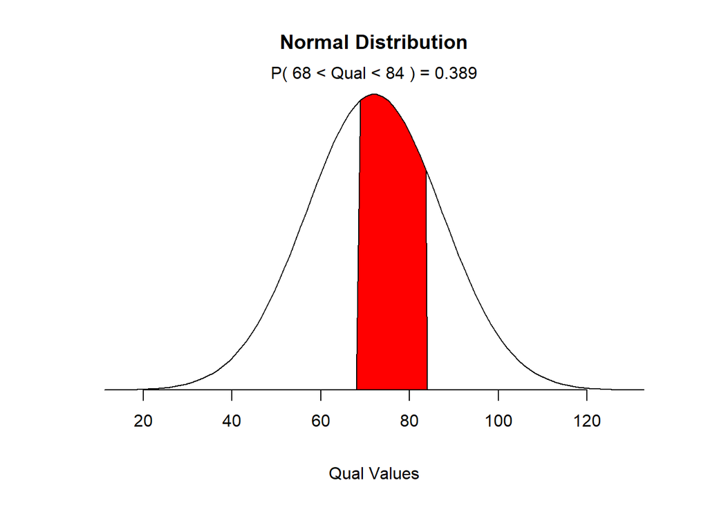

```r
mean=72; sd=15.2
lb=68; ub=84


x <- seq(-4,4,length=100)*sd + mean
hx <- dnorm(x,mean,sd)

plot(x, hx, type="n", xlab="Qual Values", ylab="",
     main="Normal Distribution", axes=FALSE)

i <- x >= lb & x <= ub
lines(x, hx)
polygon(c(lb,x[i],ub), c(0,hx[i],0), col="red")

area <- pnorm(ub, mean, sd) - pnorm(lb, mean, sd)
result <- paste("P(",lb,"< Qual <",ub,") =",
                signif(area, digits=3))
mtext(result,3)
axis(1, at=seq(20, 120, 20), pos=0)
```

```r
pnorm(68, mean, sd)
```

```
## [1] 0.3962144
```

```r
pnorm(84, mean = 72, sd=15.2) - pnorm(68, mean, sd)
```

```
## [1] 0.388868
```

```r
#Percentil
qnorm(0.95, mean = 72, sd=15.2)
```

```
## [1] 97.00178
```

```r
qnorm(0.99, mean = 72, sd=15.2)
```

```
## [1] 107.3605
```

```r
qnorm(0.50, mean = 72, sd=15.2)
```

```
## [1] 72
```

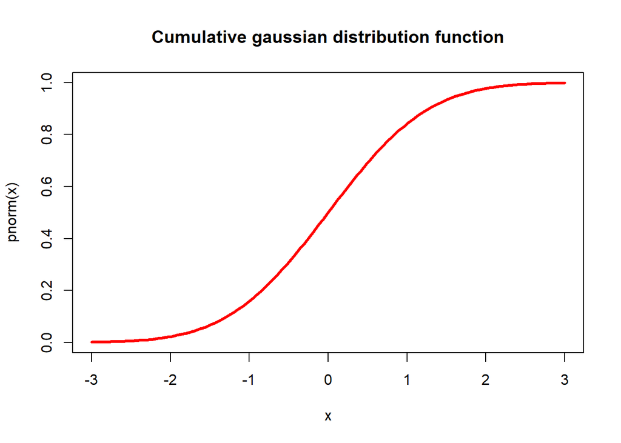

```r
curve(pnorm(x), xlim=c(-3,3), col='red', lwd=3)
title(main='Cumulative gaussian distribution function')
```

### 1.2.La distribución Chi cuadrado